# Veri Analizi Vize Sınavı

Cevap Kağıdı

Emrah Kırdök, Ph. D.

04/10/2022

# Bilimsel hikaye

Bir araştırma grubundaki araştırmacılar; *Gümüş ağacı* bitkisinde farklı patojen inokülasyonu (patojen etkenine maruz bırakma) ve kültürleme koşullarında, fotosentez hızı ve iletkenlik cevaplarını incelemeyi amaçlıyorlar.

Maalesef bu çalışma grubunda veri analizi üzerine uzmanlaşmış birisi bulunmuyor. Bu nedenle sizden yardım istiyorlar. Lütfen bu araştırma ekibine yardım ediniz.

## Çalışma yöntemi

Bu kapsamda 157 farklı gümüş ağacı biktisini çalışmaya dahil ediyorlar.

Bitkileri, dört farklı patojen (`Patojen` değişkeni) uygulamasına maruz bırakıyorlar:

- `Kontrol` (Patojen inoküle edilmemiş, sağlıklı)
- `P. cinnamomi`
- `P. multivora`
- `Patojenler` (Her iki patojen ile inoküle edilmiş bitkiler)

Ardından bu bitkileri 37 güne kadar iki farklı kültürleme koşulunda (`Kulturleme_kosulu` değişkeni) yetiştiriyorlar:

- `Kurak`
- `Nemli`

Bu süre boyunca, kültürlenen bitkilerde iki farklı ölçüm yapıyorlar:

- `Fotosentez`: Bitkide gözlenen Fotosentez hızı
- `Iletkenlik`: Bitkinin sahip olduğu iletkenlik değeri

# Veri yükleme

Uzaktan eğitim sistemine yüklenen veriyi indirip, R içerisine yükleyiniz:

```r
data <- read.table(file = "source/data/gumus_agaci.txt", header = TRUE, sep = "\t")
```

# Veri çerçevesi inceleme

Yüklediğiniz veri çerçevesinin satır ve sütun sayılarını geri döndürünüz:

```r
dim(data)
```

```
## [1] 1534    8
```

Bu veri çerçevesindeki sütun isimlerini geri döndürebilir misiniz?

```r
colnames(data)
```

```
## [1] "Inokulasyondan_sonra_gecen_sure" "Kulturleme_kosulu"
## [3] "Patojen"                         "Bitki_numarasi"
## [5] "Tekil_bitki_numarasi"            "Gozlem"
## [7] "Fotosentez"                      "Iletkenlik"
```

BU veri çerçevesinde aşağıdaki sütun isimlerinin kategori (*faktör*) değişkeni olarak belirlenmesi gerekmektedir. Acaba bu sütunları faktöre çevirebilir misiniz?

- `Kulturleme_kosulu`
- `Patojen`

```r
data$Kulturleme_kosulu <- as.factor(data$Kulturleme_kosulu)
data$Patojen <- as.factor(data$Patojen)
```

# Koşulların belirlenmesi

Bu deney kapsamında yapılmış kültürleme koşullarını (Kurak veya Nemli) frekans tablosu haline getirebilir misiniz?

```r
table(data$Kulturleme_kosulu)
```

```
##
## Kurak Nemli
##   680   854
```

Bu deney kapsamında yapılmış patojen uygulamalarını frekans tablosu haline getirebilir misiniz?

```r
table(data$Patojen)
```

```
##
##       Kontrol P. cinnamomi  P. multivora     Patojenler
##           550           412           506            66
```

Acaba her farklı kültürleme koşuluna ait kaç farklı patojen uygulaması var? Birleşik bir frekans tablosu oluşturabilir misiniz?

```r
table(data$Kulturleme_kosulu, data$Patojen)
```

```
##
##         Kontrol P. cinnamomi  P. multivora  Patojenler
##   Kurak     223           189           220         48
##   Nemli     327           223           286         18
```

# Fotosentez hızı ve iletkenlik değerlerinin dağılımları

Bu veri setinde fotosentez hızı ve iletkenlik hakkında ölçümler alınmıştır. Bu değişkenlere ait histogramları `ggplot2` paketi kullanarak çizebilir misiniz?

İlk olarak Fotosentez hızı değişkeni:

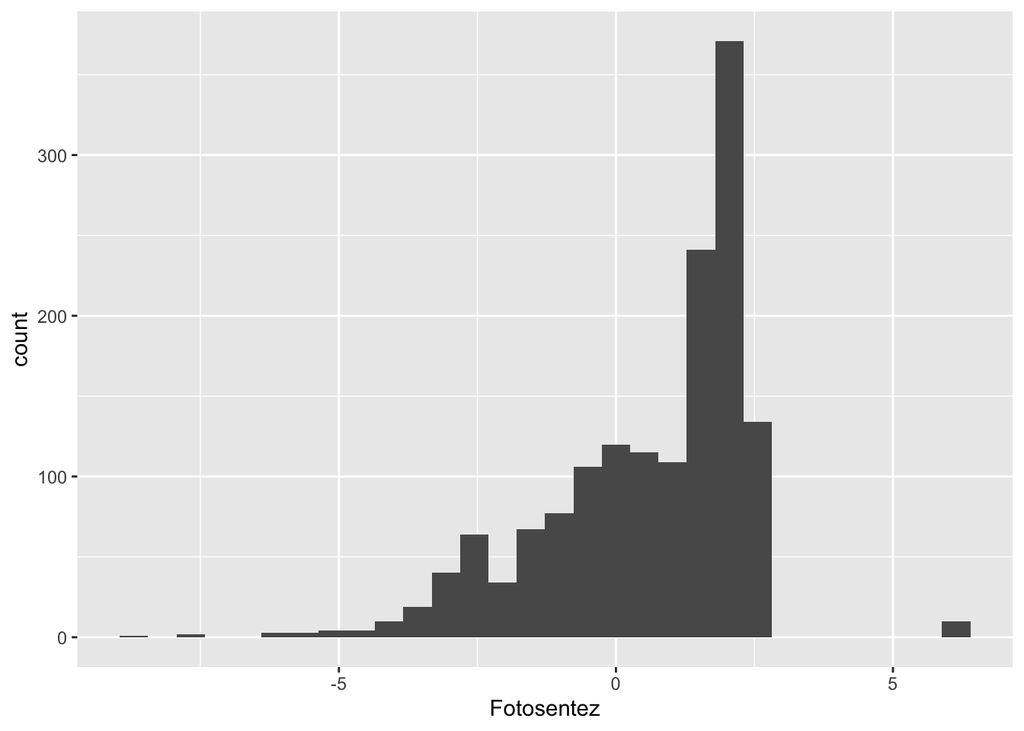

```r
library(ggplot2)
ggplot(data = data, aes(x=Fotosentez)) + geom_histogram()
```

Şimdi de iletkenlik değerleri:

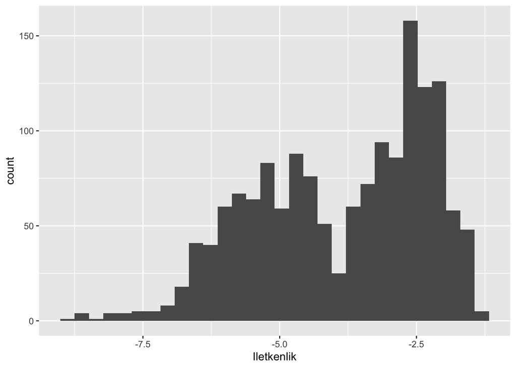

```r
ggplot(data = data, aes(x=Iletkenlik)) + geom_histogram()
```

# Fotosentez hızında görülen değişimlerin incelenmesi

Bu kısımda ise fotosentez hızında görülen değişimleri incelemeyi amaçladık.

## Kültürleme koşulları ve Fotosentez hızı

Acaba farklı kültürleme koşulları (Kurak veya Nemli) fotosentez hızına nasıl etki gösteriyor? Bunu kutu grafiği (boxplot) kullanarak görselleştirebilir misiniz?

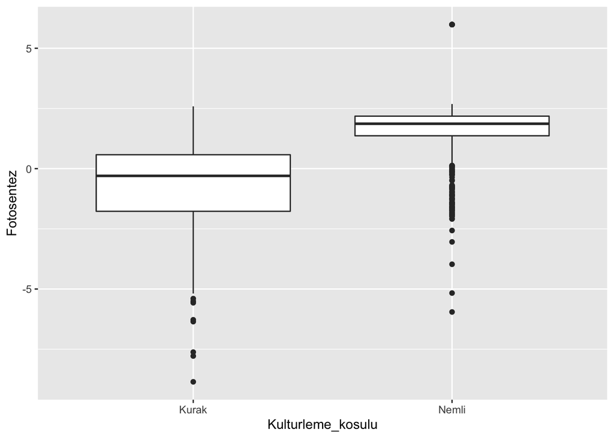

```r
ggplot(data = data, aes(x=Kulturleme_kosulu, y = Fotosentez)) + geom_boxplot()
```

Sizce fotosentez hızı kültürleme koşulundan nasıl etkilenmiş olabilir? Kurak kültürleme koşullaru, fotosentez hızında bir değişime yol açmış olabilir mi? Cevabınızı aşağıya yazınız:

## Patojen inokülasyonu ve Fotosentez hızında görülen değişim

Patojen inokulasyonu acaba fotosentez hızında ne gibi değişime yol açmış? Uygulanan patojen türlerinin, Fotosentez dağılımına etkisini kutu grafiği olarak gösterebilir misiniz?

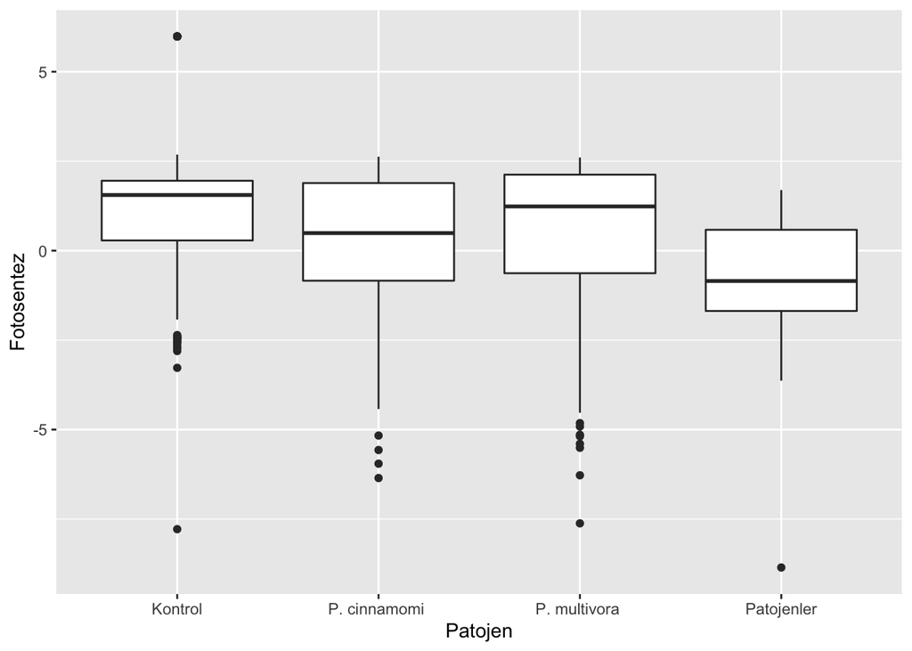

```r
ggplot(data = data, aes(x=Patojen, y = Fotosentez)) + geom_boxplot()
```

Yukarıda oluşturduğunuz grafiğe bakarak aşağıdaki soruları cevaplayınız:

Acaba patojen uygulaması fotosentez hızında bir değişime yol açmış olabilir mi?

Aynı anda iki patojenin uygulanması, fotosentez hızını biraz daha fazla azaltmış olabilir mi?

# İletkenlik değerinde görülen değişimler

Bu kısımda ise kontrol bitkileri ve patojen uygulanmış bitkilerin iletkenlik değerlerinde görülen değişimlerin incelenmesi amaçlanmıştır.

## Kültürleme koşulları ve iletkenlik

Acaba farklı kültürleme koşullarının, bitkilerin iletkenlik değerlerinde ne gibi etkisi var? Farklı kültürleme koşullarındaki iletkenlik değerlerini kutu grafiği (boxplot) ile görselleştirebilir misiniz?

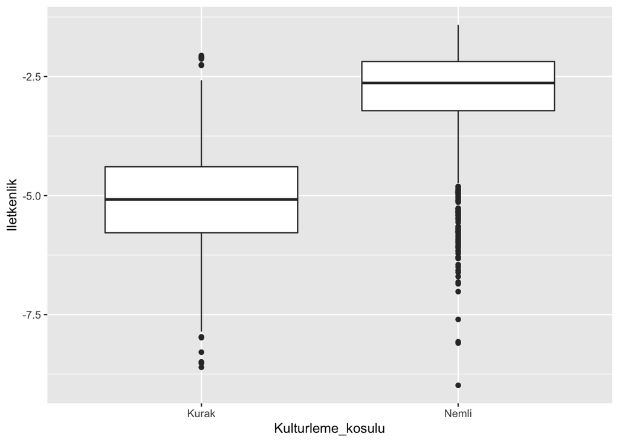

```r
ggplot(data = data, aes(x=Kulturleme_kosulu, y = Iletkenlik)) + geom_boxplot()
```

Kurak kültürleme koşulları, iletkenlik değerine nasıl bir etki gösteriyor? Aşağıda bir cümle ile açıklayınız:

## Patojen inokülasyonun iletkenlik değerlerine etkisi

Patojen inokulasyonu acaba iletkenlik değerlerinde ne gibi değişime yol açmış olabilir? Uygulanan patojen türlerinin, iletkenlik değerlerine etkisini kutu grafiği olarak gösterebilir misiniz?

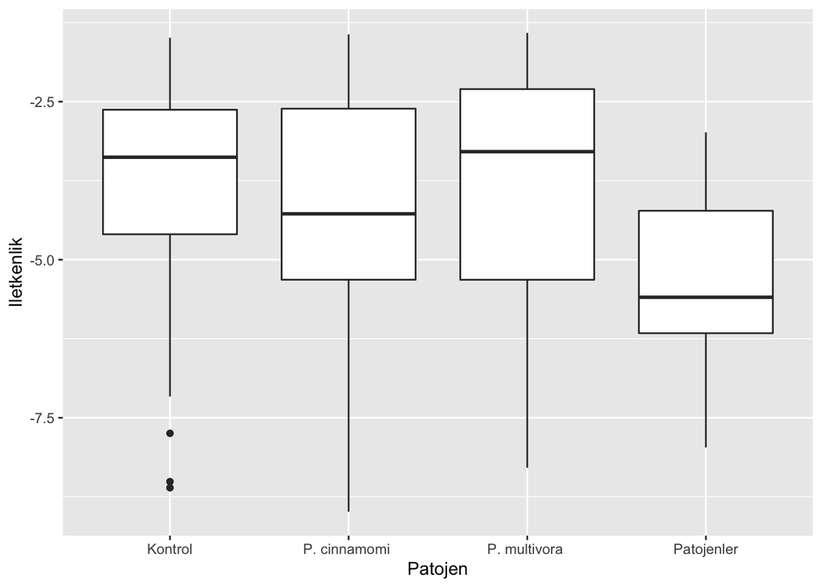

```r
ggplot(data = data, aes(x=Patojen, y = Iletkenlik)) + geom_boxplot()
```

# Fotosentez hızının kontrol örneklerinde incelenmesi

Bu kısımda sadece kontrol (patojen uygulaması yapılmamış) bitkilerdeki fotosentez hızının, kurak ve nemli koşullardaki değişimini inceleyeceğiz.

Sadece `Kontrol` örneklerinin olduğu yeni bir veri çerçevesi oluşturabilir misiniz?

```r
kontrol <- data[data$Patojen == "Kontrol", ]
```

Şimdi ise, oluşturduğunuz yeni veri çerçevesini kullanarak Fotosentez hızının farklı kültürleme koşullarındaki değişimini gösteren kutu grafiğini çiziniz:

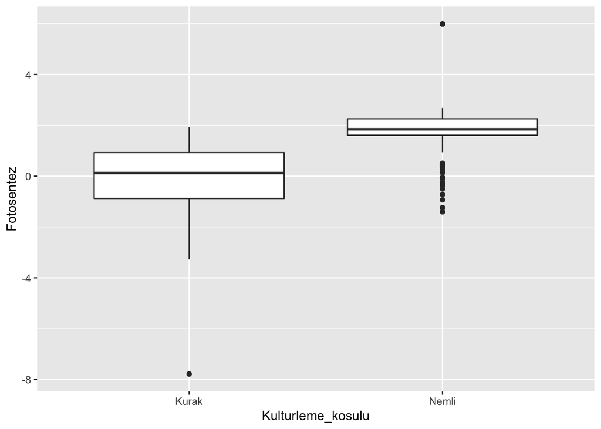

```r
ggplot(data = kontrol, aes(x=Kulturleme_kosulu, y = Fotosentez)) + geom_boxplot()
```

# İletkenlik ve Fotosentez arasında bir ilişki var mı?

Peki iletkenlik ve fotosentez hızı arasında bir ilişki var mı? Bu iki değişkeni x-y ekseninde nokta grafiği ile gösterebilir misiniz? Eksenleri aşağıdaki gibi belirleyiniz:

- `x` ekseni: İletkenlik
- `y` ekseni: Fotosentez hizi

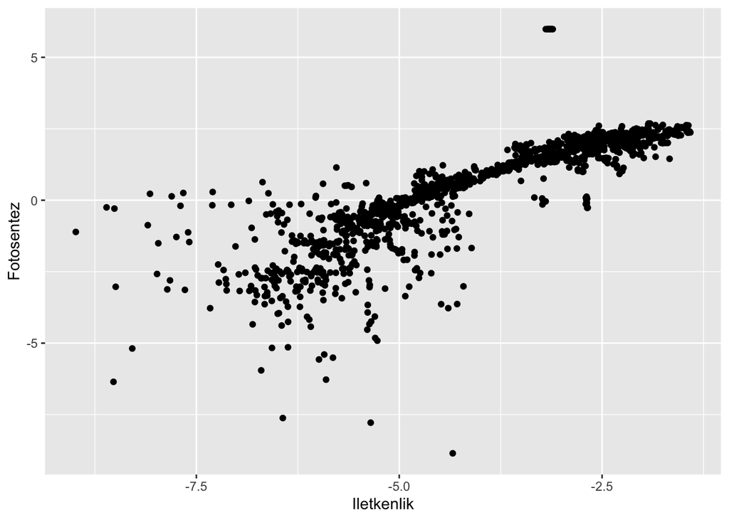

```r
ggplot(data=data, aes(x=Iletkenlik, y=Fotosentez)) + geom_point()
```

# Bonus: Acaba fotosentez hızındaki değişim anlamlı mı?

Acaba `Kurak` ve `Nemli` koşullarda kültürlenen bitkilerin fotosentez hızlarında anlamlı bir değişim var mı? `t.test` fonksiyonu ile bu iki kategorinin ortalamaları arasındaki farklın anlamlı olup olmadığını belirleyiniz. `p-value` (p-değeri) anlamlılık analizi için 0.001 eşiğini kullanınız:

```r
kurak <- data$Fotosentez[data$Kulturleme_kosulu=="Kurak"]
nemli <- data$Fotosentez[data$Kulturleme_kosulu=="Nemli"]

test <- t.test(x=kurak, y = nemli)
test$p.value < 0.001
```

```
## [1] TRUE
```